# PCA_HLA

Magdalena Grose-Hodge

21/02/2023

install packages

load packages

```r
library(tidyverse)
library(broom)
library(Hmisc)
library(factoextra)
```

set working directory

```r
setwd("/Users/magdalenagrose-hodge/Desktop/OneDrive - University of Birmingham/Predictors of HLA DC1 Study 2/Predictors of HLA codes/PCA_HLA_predictors")
```

import, read and merge data

```r
allData <- read_csv("Data_anonymised.csv")
```

check data

```r
summary(allData)
```

```
##  Participant            eMLAT           PNT_pl          PNT_en
##  Length:78          Min.   : 2.00   Min.   :17.00   Min.   :13.00
##  Class :character   1st Qu.: 8.50   1st Qu.:27.50   1st Qu.:20.00
##  Mode  :character   Median :18.00   Median :35.00   Median :25.00
##                     Mean   :15.29   Mean   :38.37   Mean   :27.29
##                     3rd Qu.:21.00   3rd Qu.:44.50   3rd Qu.:32.00
##                     Max.   :26.00   Max.   :84.00   Max.   :50.00
##                     NA's   :3       NA's   :3       NA's   :3
##     Read_pl         Read_en        Age_decim         TROG_pl
##  Min.   : 4.00   Min.   : 5.00   Min.   : 7.250   Min.   :51.00
##  1st Qu.:21.50   1st Qu.:50.50   1st Qu.: 7.917   1st Qu.:68.00
##  Median :35.00   Median :68.00   Median : 8.833   Median :71.00
##  Mean   :35.64   Mean   :63.79   Mean   : 9.160   Mean   :70.80
##  3rd Qu.:45.00   3rd Qu.:80.00   3rd Qu.:10.080   3rd Qu.:74.75
##  Max.   :92.00   Max.   :96.00   Max.   :12.333   Max.   :80.00
##  NA's   :3       NA's   :3       NA's   :1        NA's   :4
##     MLTU_pl        LexDiv_pl       Subindex_pl       DflR_pl
##  Min.   :3.800   Min.   :0.3300   Min.   :1.000   Min.   : 4.140
##  1st Qu.:4.888   1st Qu.:0.4900   1st Qu.:1.110   1st Qu.: 9.162
##  Median :5.445   Median :0.5300   Median :1.160   Median :13.100
##  Mean   :5.529   Mean   :0.5245   Mean   :1.168   Mean   :13.557
##  3rd Qu.:5.997   3rd Qu.:0.5600   3rd Qu.:1.222   3rd Qu.:16.642
##  Max.   :8.150   Max.   :0.6300   Max.   :1.450   Max.   :28.800
##  NA's   :2       NA's   :2        NA's   :2       NA's   :2
##   Retracing_pl   Repetitions_pl     Pauses_pl      Filled_pauses_pl
##  Min.   :0.000   Min.   :0.0000   Min.   : 1.580   Min.   :0.000
##  1st Qu.:0.770   1st Qu.:0.7675   1st Qu.: 5.697   1st Qu.:0.785
##  Median :1.185   Median :1.4950   Median : 6.915   Median :2.090
##  Mean   :1.313   Mean   :1.9270   Mean   : 7.850   Mean   :2.467
##  3rd Qu.:1.705   3rd Qu.:2.7475   3rd Qu.: 9.213   3rd Qu.:3.335
##  Max.   :3.160   Max.   :7.0000   Max.   :19.340   Max.   :9.130
##  NA's   :2       NA's   :2        NA's   :2        NA's   :2
##   Breakdown_pl      Repair_pl     Phonationtime_pl Mean_Length_of_Run_pl
##  Min.   : 2.760   Min.   :0.000   Min.   :33.00    Min.   : 5.92
##  1st Qu.: 7.503   1st Qu.:1.677   1st Qu.:55.35    1st Qu.: 9.74
##  Median : 9.440   Median :2.705   Median :64.11    Median :11.43
##  Mean   :10.318   Mean   :3.240   Mean   :64.11    Mean   :12.17
##  3rd Qu.:12.830   3rd Qu.:4.308   3rd Qu.:73.40    3rd Qu.:13.87
##  Max.   :24.720   Max.   :8.750   Max.   :94.08    Max.   :25.88
##  NA's   :2        NA's   :2       NA's   :2        NA's   :2
```

[output cut: 73 more lines]

```
##  Min.   :0.770   Min.   : 7.220   Min.   : 3.150   Min.   :4.300
##  1st Qu.:1.520   1st Qu.: 7.920   1st Qu.: 5.530   1st Qu.:4.700
##  Median :2.170   Median : 8.800   Median : 6.760   Median :4.900
##  Mean   :2.701   Mean   : 9.081   Mean   : 6.926   Mean   :4.848
##  3rd Qu.:3.340   3rd Qu.: 9.950   3rd Qu.: 8.240   3rd Qu.:5.000
##  Max.   :8.000   Max.   :12.170   Max.   :11.030   Max.   :5.000
##  NA's   :13      NA's   :13       NA's   :13       NA's   :13
##     Qual_en        No_excl_pl
##  Min.   :4.100   Min.   :0.0000
##  1st Qu.:4.900   1st Qu.:0.0000
##  Median :5.000   Median :0.0000
##  Mean   :4.908   Mean   :0.8281
##  3rd Qu.:5.000   3rd Qu.:2.0000
##  Max.   :5.000   Max.   :4.0000
##  NA's   :13      NA's   :14
```

create a dataset for Polish fluency measures only

```r
fluency_pl <-  allData %>%
  select (DflR_pl, Retracing_pl, Repetitions_pl, Pauses_pl, Filled_pauses_pl, Breakdown_pl, Repair_pl, Phonationtime_pl, Mean_Length_of_Run_pl, Speechrate_pl, ArtR_pl, ASD_pl)
```

filter dataset: remove participants with missing values

```r
fluency_pl_1 <- na.omit(fluency_pl)
```

scaling the data [purpose of scaling is to standardize the variance across variables] and running PCA

```r
pca <- prcomp(fluency_pl_1, center = TRUE,scale. = TRUE)
```

look at proportion of variance

```r
summary(pca)
```

```
## Importance of components:
##                           PC1    PC2    PC3    PC4     PC5     PC6     PC7
## Standard deviation     2.2772 1.5845 1.2735 1.1212 0.83795 0.71008 0.43830
## Proportion of Variance 0.4321 0.2092 0.1351 0.1048 0.05851 0.04202 0.01601
## Cumulative Proportion  0.4321 0.6414 0.7765 0.8813 0.93977 0.98179 0.99780
##                            PC8     PC9     PC10     PC11      PC12
## Standard deviation     0.14489 0.07370 0.001899 0.000838 0.0006438
## Proportion of Variance 0.00175 0.00045 0.000000 0.000000 0.0000000
## Cumulative Proportion  0.99955 1.00000 1.000000 1.000000 1.0000000
```

explain variance

```r
var_explained <- pca$sdev^2 / sum(pca$sdev^2)
var_explained
```

```
##  [1] 4.321252e-01 2.092304e-01 1.351400e-01 1.047623e-01 5.851317e-02
##  [6] 4.201728e-02 1.600910e-02 1.749544e-03 4.526075e-04 3.006483e-07
## [11] 5.851943e-08 3.454313e-08
```

screeplot

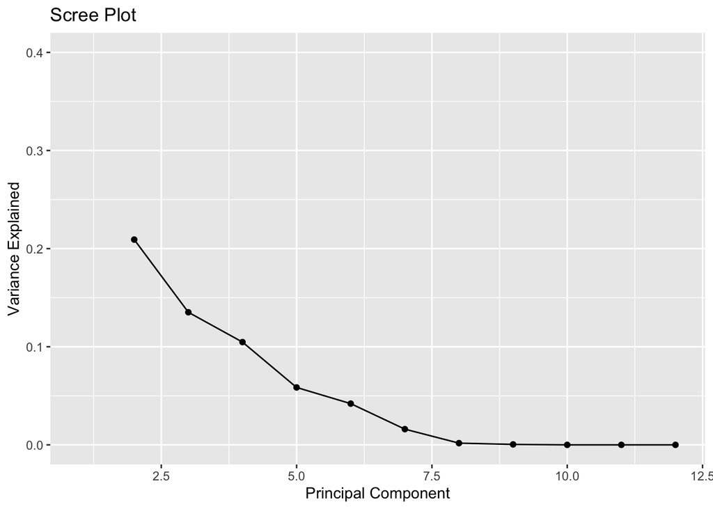

```r
qplot(c(1:12), var_explained) +
  geom_line() +
  xlab("Principal Component") +
  ylab("Variance Explained") +
  ggtitle("Scree Plot") +
  ylim(0, 0.40)
```

Eigenvalue [The idea behind this is that if the eigenvalue is less than 1, then the component accounts for less variance than a single variable contributed]

```r
pca$sdev ^ 2
```

```
##  [1] 5.185502e+00 2.510765e+00 1.621680e+00 1.257148e+00 7.021580e-01
##  [6] 5.042073e-01 1.921092e-01 2.099453e-02 5.431289e-03 3.607780e-06
## [11] 7.022331e-07 4.145176e-07
```

which variables contribute to any given component

```r
print(pca$rotation)
```

```
##                              PC1         PC2         PC3          PC4
## DflR_pl               -0.4137972 -0.10414990 -0.11375388  0.209205582
## Retracing_pl          -0.3139507 -0.01199210 -0.26106632 -0.005460421
## Repetitions_pl        -0.2577460  0.11658635 -0.45003317 -0.376835099
## Pauses_pl             -0.3295368 -0.21306863 -0.03384310  0.263895036
## Filled_pauses_pl      -0.2573991  0.00261583  0.16746897  0.387245518
## Breakdown_pl          -0.3743160 -0.16475943  0.05024533  0.382728396
## Repair_pl             -0.3208670  0.08636527 -0.45033318 -0.295367601
## Phonationtime_pl      -0.3248092  0.13681406  0.42139380 -0.236441741
## Mean_Length_of_Run_pl -0.2231659  0.36441904  0.34363745 -0.269500160
## Speechrate_pl         -0.2556123  0.43950733  0.29314304 -0.037574819
## ArtR_pl                0.1103460  0.53053522 -0.21530048  0.335257674
## ASD_pl                -0.1141890 -0.51889620  0.23219009 -0.344283578
##                               PC5         PC6         PC7           PC8
## DflR_pl                0.01368785 -0.12923970 -0.03962339  0.0009050851
## Retracing_pl           0.14572396  0.84698093 -0.08376784  0.0013934118
## Repetitions_pl        -0.21361442 -0.40199220  0.06859777 -0.0010528917
## Pauses_pl              0.53571804 -0.25133353 -0.02458949  0.0233103532
## Filled_pauses_pl      -0.77210455  0.06962475 -0.08416982 -0.0343746652
## Breakdown_pl           0.06398765 -0.16380329 -0.05788477  0.0027429489
## Repair_pl             -0.11134707  0.01047501  0.02039762 -0.0030257417
## Phonationtime_pl       0.04004464  0.04783074  0.47350793  0.0712032074
## Mean_Length_of_Run_pl  0.09669498 -0.06741377 -0.77903324 -0.0434818190
## Speechrate_pl          0.08486147  0.02643243  0.37404982 -0.0420880494
## ArtR_pl                0.05518091 -0.02783639 -0.01443995  0.7244344898
## ASD_pl                -0.11006504  0.03254749 -0.06345892  0.6817016667
##                                 PC9          PC10          PC11          PC12
## DflR_pl               -0.0044010364  0.0519846110  1.373751e-01  8.492131e-01
## Retracing_pl          -0.0009776209 -0.2918694961  1.352072e-03 -4.779092e-02
## Repetitions_pl         0.0089899480 -0.5949372249  2.945743e-03 -9.728659e-02
## Pauses_pl              0.0018084900 -0.0359202778 -6.178620e-01 -2.021483e-01
## Filled_pauses_pl      -0.0103705898 -0.0219066235 -3.629693e-01 -1.189141e-01
## Breakdown_pl          -0.0037167046  0.0040133859  6.819370e-01 -4.293997e-01
## Repair_pl             -0.0008570545  0.7458786309 -5.078360e-02 -1.664202e-01
## Phonationtime_pl      -0.6396255942 -0.0031571420 -1.896038e-04 -1.236046e-03
## Mean_Length_of_Run_pl -0.0632429348 -0.0010139427 -7.316584e-05 -5.281014e-07
## Speechrate_pl          0.7103137073  0.0043056493  3.921819e-04  1.380340e-03
## ArtR_pl               -0.1370037752  0.0006264766 -2.252760e-04  1.198102e-04
## ASD_pl                 0.2516690704  0.0028919310 -4.641041e-05  8.121319e-04
```

another way of plotting the results and looking at the contributions

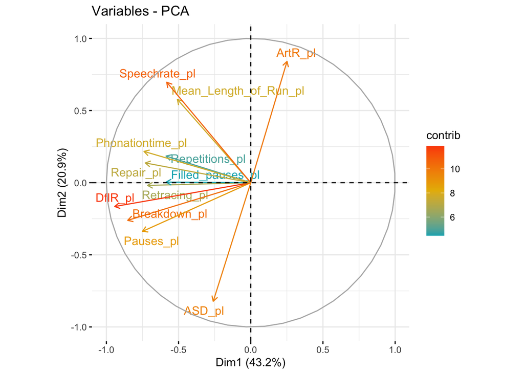

```r
fviz_pca_var(pca,
             col.var = "contrib", # Color by contributions to the PC
             gradient.cols = c("#00AFBB", "#E7B800", "#FC4E07"),
             repel = TRUE)    # Avoid text overlapping
```

ENGLISH

create a dataset for English fluency measures only

```r
fluency_en <-  allData %>%
  select (DflR_en, Retracing_en, Repetitions_en, Pauses_en, Filled_pauses_en, Breakdown_en, Repair_en, Phonationtime_en, Mean_Length_of_run_en, Speechrate_en, ArtR_en, ASD_en)
```

filter dataset: remove participants with missing values

```r
fluency_en_1 <- na.omit(fluency_en)
```

scaling the data [purpose of scaling is to standardize the variance across variables] and running PCA

```r
pca_en <- prcomp(fluency_en_1, center = TRUE,scale. = TRUE)
```

look at proportion of variance

```r
summary(pca_en)
```

```
## Importance of components:
##                           PC1    PC2    PC3    PC4     PC5     PC6     PC7
## Standard deviation     2.0739 1.5736 1.3965 1.2620 0.86552 0.81615 0.49744
## Proportion of Variance 0.3584 0.2064 0.1625 0.1327 0.06243 0.05551 0.02062
## Cumulative Proportion  0.3584 0.5648 0.7273 0.8600 0.92243 0.97794 0.99856
##                            PC8     PC9     PC10      PC11      PC12
## Standard deviation     0.11134 0.06974 0.001953 0.0008375 0.0005984
## Proportion of Variance 0.00103 0.00041 0.000000 0.0000000 0.0000000
## Cumulative Proportion  0.99959 1.00000 1.000000 1.0000000 1.0000000
```

explain variance

```r
var_explained_en <- pca_en$sdev^2 / sum(pca_en$sdev^2)
var_explained_en
```

```
##  [1] 3.584268e-01 2.063565e-01 1.625089e-01 1.327135e-01 6.242642e-02
##  [6] 5.550842e-02 2.062075e-02 1.033023e-03 4.052972e-04 3.177927e-07
## [11] 5.844481e-08 2.984135e-08
```

screeplot

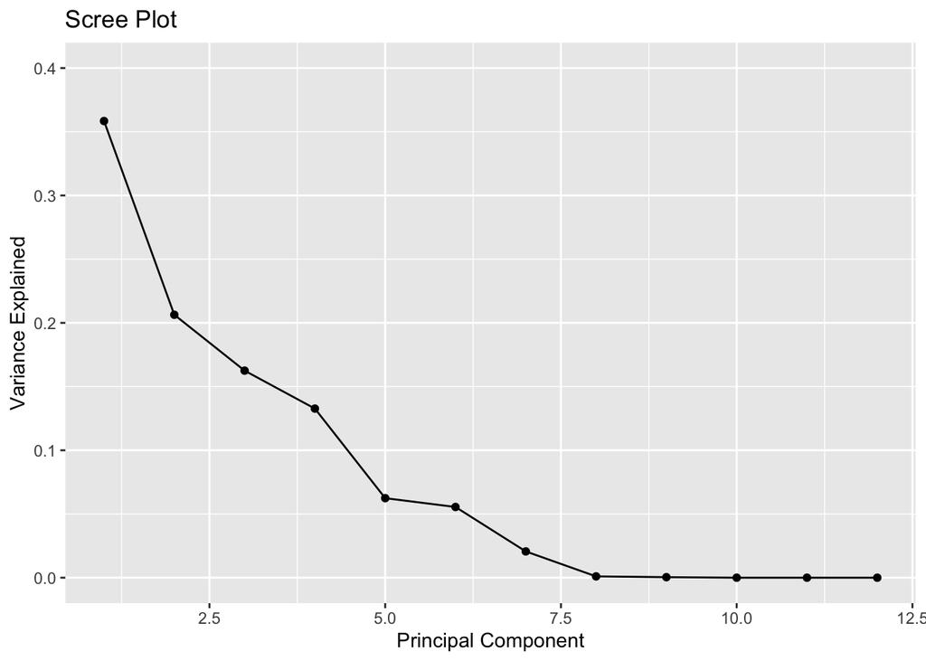

```r
qplot(c(1:12), var_explained_en) +
  geom_line() +
  xlab("Principal Component") +
  ylab("Variance Explained") +
  ggtitle("Scree Plot") +
  ylim(0, 0.40)
```

Eigenvalue [The idea behind this is that if the eigenvalue is less than 1, then the component accounts for less variance than a single variable contributed]

```r
pca_en$sdev ^ 2
```

```
##  [1] 4.301121e+00 2.476278e+00 1.950107e+00 1.592562e+00 7.491171e-01
##  [6] 6.661010e-01 2.474489e-01 1.239628e-02 4.863567e-03 3.813513e-06
## [11] 7.013377e-07 3.580962e-07
```

which variables contribute to any given component

```r
print(pca_en$rotation)
```

```
##                              PC1         PC2         PC3         PC4
## DflR_en               -0.4358795  0.14522683 -0.25024090  0.06412574
## Retracing_en          -0.2222573  0.11885219  0.17628778  0.38569610
## Repetitions_en        -0.3124041 -0.12319691  0.12137399  0.43005324
## Pauses_en             -0.3284142  0.26821426 -0.31294484 -0.11312335
## Filled_pauses_en      -0.2133755 -0.08570381 -0.33490176 -0.21202135
## Breakdown_en          -0.3583859  0.20053239 -0.38819979 -0.17258591
## Repair_en             -0.3449678 -0.04939138  0.17166828  0.50789313
## Phonationtime_en      -0.3037179 -0.34117171  0.24203188 -0.30320118
## Mean_Length_of_run_en -0.2092458 -0.48271342  0.08859327 -0.17471365
## Speechrate_en         -0.1793840 -0.55185261 -0.04214512 -0.10855192
## ArtR_en                0.2181716 -0.30045934 -0.45216113  0.31394589
## ASD_en                -0.2153611  0.28886255  0.47817740 -0.28963424
##                               PC5         PC6         PC7          PC8
## DflR_en               -0.01025187 -0.05208929  0.01376765  0.004282161
## Retracing_en          -0.49522820  0.63760026  0.04561886 -0.022305338
## Repetitions_en         0.42334113 -0.35638968 -0.04568374 -0.001343782
## Pauses_en             -0.33068183 -0.30992796  0.05294618  0.012742839
## Filled_pauses_en       0.58155449  0.60210074 -0.05804977  0.002051683
## Breakdown_en          -0.07853183 -0.05324472  0.02521790  0.011665977
## Repair_en              0.13413723 -0.02044136 -0.01717893 -0.011912495
## Phonationtime_en      -0.15797912 -0.03444855 -0.35337874 -0.460816331
## Mean_Length_of_run_en -0.06379073 -0.01144145  0.82300308 -0.014971600
## Speechrate_en         -0.21998014 -0.01095108 -0.42811324  0.449419440
## ArtR_en               -0.12627609 -0.01376206  0.03403660  0.376107680
## ASD_en                 0.10171774  0.01669106  0.04345346  0.665602793
##                                PC9          PC10          PC11          PC12
## DflR_en                0.002365850 -1.294050e-01  4.317470e-01  7.183332e-01
## Retracing_en          -0.008226057  3.170867e-01  6.498049e-03 -4.024235e-02
## Repetitions_en        -0.000796089  6.108047e-01  1.280151e-02 -7.734164e-02
## Pauses_en             -0.010813058  1.021727e-01 -6.980434e-01  5.728464e-02
## Filled_pauses_en       0.029499753  4.236010e-02 -2.875584e-01  2.354080e-02
## Breakdown_en           0.002589986 -1.188253e-02  4.547900e-01 -6.588666e-01
## Repair_en              0.004578668 -7.051304e-01 -1.913107e-01 -1.960992e-01
## Phonationtime_en       0.526744330  3.862695e-03 -2.499708e-04 -5.815339e-05
## Mean_Length_of_run_en -0.055424990  3.175281e-06 -1.323158e-04 -8.033008e-05
## Speechrate_en         -0.464688860 -3.818828e-03  2.835234e-04 -6.489422e-06
## ArtR_en                0.632732336  3.549701e-03 -1.193630e-04  5.198573e-04
## ASD_en                 0.319521215  1.440429e-03  2.119867e-05  4.114319e-04
```

another way of plotting the results and looking at the contributions

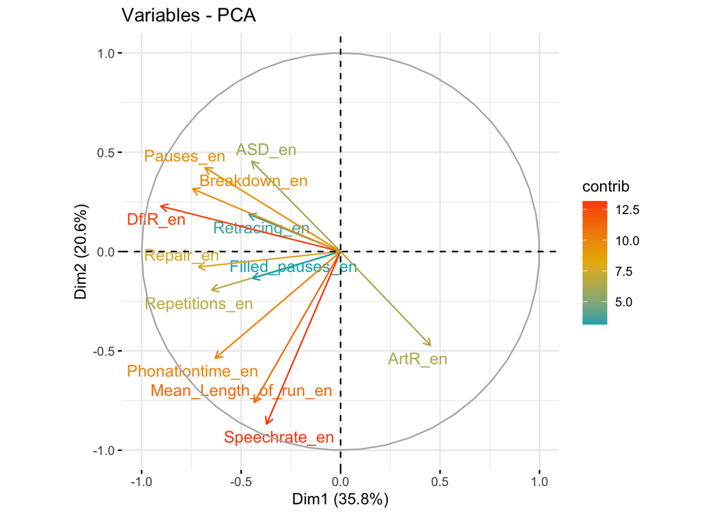

```r
fviz_pca_var(pca_en,
             col.var = "contrib", # Color by contributions to the PC
             gradient.cols = c("#00AFBB", "#E7B800", "#FC4E07"),
             repel = TRUE)    # Avoid text overlapping
```